# Homework 2

PSTAT 131/231

## Linear Regression

For this lab, we will be working with a data set from the UCI (University of California, Irvine) Machine Learning repository ([see website here](http://archive.ics.uci.edu/ml/datasets/Abalone)). The full data set consists of $4,177$ observations of abalone in Tasmania. (Fun fact: Tasmania supplies about $25\%$ of the yearly world abalone harvest.)

The age of an abalone is typically determined by cutting the shell open and counting the number of rings with a microscope. The purpose of this data set is to determine whether abalone age (**number of rings + 1.5**) can be accurately predicted using other, easier-to-obtain information about the abalone.

The full abalone data set is located in the `\data` subdirectory. Read it into *R* using `read_csv()`. Take a moment to read through the codebook (`abalone_codebook.txt`) and familiarize yourself with the variable definitions.

Make sure you load the `tidyverse` and `tidymodels`!

### Question 1

Your goal is to predict abalone age, which is calculated as the number of rings plus 1.5. Notice there currently is no `age` variable in the data set. Add `age` to the data set.

Assess and describe the distribution of `age`.

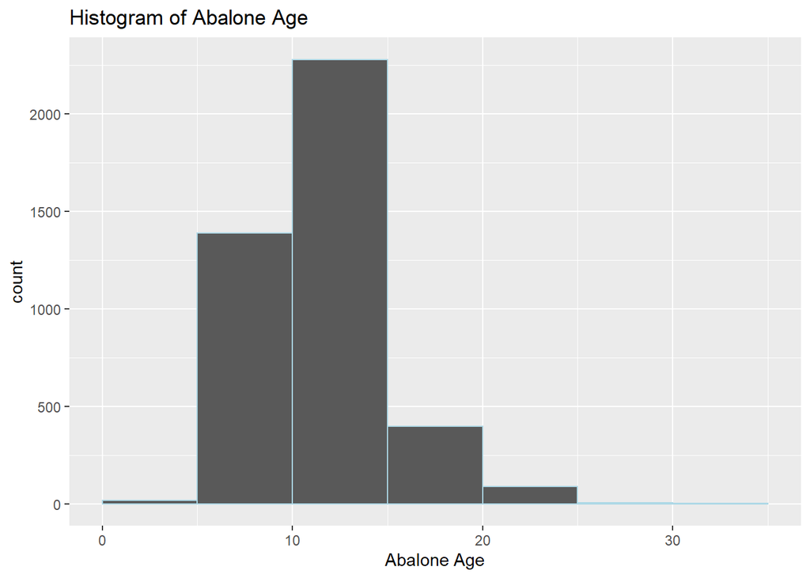

```r
library(tidyverse)
library(ggplot2)
library(reticulate)
py_install("pandas")
py_install("scikit-learn")
data <- read.csv(file = "C:/Users/ianlo/Documents/Classes/PSTAT 131/Homeworks/hw2_ianlow/homework-2/data/abalone.csv")
data$age <- data$rings + 1.5
ggplot(data, aes(x=age)) +
  geom_histogram(color='light blue', binwidth=5, boundary=0) +
  labs(title="Histogram of Abalone Age", x="Abalone Age")
```

#### Answer:

The vast majority of Abalones are estimated between 5 to 15 years old, and the age distribution tails off to 25+ years old.

### Question 2

Split the abalone data into a training set and a testing set. Use stratified sampling. You should decide on appropriate percentages for splitting the data.

*Remember that you’ll need to set a seed at the beginning of the document to reproduce your results.*

```python
#using python to stratify sample for fun
import pandas as pd
from sklearn.model_selection import train_test_split
python_data = r.data
stratified = python_data["type"]

#stratifying on type, 70 train/30 test
training, testing = train_test_split(python_data, test_size=0.3, random_state = 120, stratify = stratified) #random_state is the equivalent of setting a seed
print(f"Training Set:\n{training}\n")
```

```
## Training Set:
##      type  longest_shell  diameter  ...  shell_weight  rings   age
## 1257    I          0.430     0.340  ...        0.1150      8   9.5
## 3196    I          0.325     0.245  ...        0.0450      5   6.5
## 3768    M          0.560     0.465  ...        0.2695      9  10.5
## 147     I          0.280     0.205  ...        0.0420      9  10.5
## 3267    F          0.400     0.335  ...        0.1200     10  11.5
## ...   ...            ...       ...  ...           ...    ...   ...
## 3282    F          0.580     0.475  ...        0.3050     13  14.5
## 57      M          0.470     0.385  ...        0.1700      8   9.5
## 3428    I          0.250     0.180  ...        0.0215      4   5.5
## 1746    M          0.700     0.565  ...        0.5400     10  11.5
## 1748    F          0.705     0.545  ...        0.2650     11  12.5
##
## [2923 rows x 10 columns]
```

```python
print(f"Testing Set:\n{testing}")
```

```
## Testing Set:
##      type  longest_shell  diameter  ...  shell_weight  rings   age
## 718     I          0.180     0.125  ...        0.0085      4   5.5
## 2193    I          0.215     0.170  ...        0.0200      6   7.5
## 19      M          0.450     0.320  ...        0.1150      9  10.5
## 3147    F          0.645     0.500  ...        0.3450     13  14.5
## 3698    F          0.650     0.510  ...        0.3885     10  11.5
## ...   ...            ...       ...  ...           ...    ...   ...
## 3138    M          0.510     0.400  ...        0.2300     10  11.5
## 884     M          0.660     0.520  ...        0.4000     10  11.5
## 3168    M          0.605     0.470  ...        0.3100     15  16.5
## 2521    M          0.540     0.420  ...        0.2235      9  10.5
## 1191    M          0.695     0.560  ...        0.4375     10  11.5
##
## [1254 rows x 10 columns]
```

Printing the distribution of the original, training, and testing datasets shows a relatively equal distribution of data based on the “type” attribute:

```python
original = python_data['type'].value_counts(normalize=True)
train = training['type'].value_counts(normalize=True)
test = testing['type'].value_counts(normalize=True)
print(f"Original distribution: \n {original}\n")
```

```
## Original distribution:
##  M    0.365813
## I    0.321283
## F    0.312904
## Name: type, dtype: float64
```

```python
print(f"Training distribution: \n {train}\n")
```

```
## Training distribution:
##  M    0.365720
## I    0.321245
## F    0.313035
## Name: type, dtype: float64
```

```python
print(f"Testing distribution: \n {test}\n")
```

```
## Testing distribution:
##  M    0.366029
## I    0.321372
## F    0.312600
## Name: type, dtype: float64
```

### Question 3

Using the **training** data, create a recipe predicting the outcome variable, `age`, with all other predictor variables. Note that you should not include `rings` to predict `age`. Explain why you shouldn’t use `rings` to predict `age`.

Steps for your recipe:

1. dummy code any categorical predictors
2. create interactions between
   - `type` and `shucked_weight`,
   - `longest_shell` and `diameter`,
   - `shucked_weight` and `shell_weight`
3. center all predictors, and
4. scale all predictors.

You’ll need to investigate the `tidymodels` documentation to find the appropriate step functions to use.

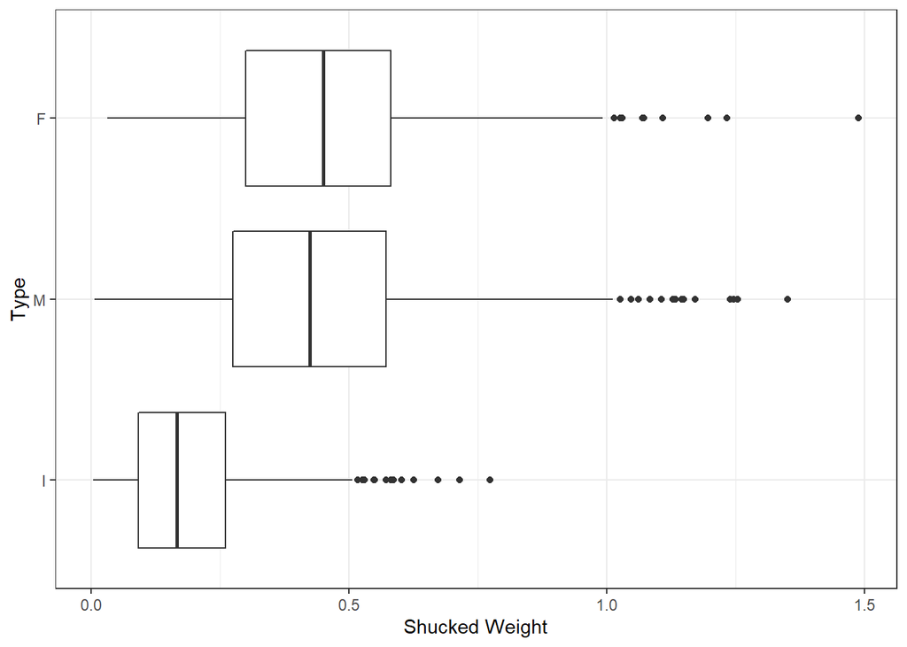

```r
library(tidymodels)
#storing the datasets created in python back into R variables
original <- py$python_data
training <- py$training
testing <- py$testing

#dummy code categorical variables
abalone_recipe1 <- recipe(age ~ ., data = training) %>%
  step_dummy(all_nominal_predictors())

#looking for relationships between predictors
training %>%
  ggplot(aes(x = shucked_weight, y = reorder(type, shucked_weight))) +
  geom_boxplot() +
  theme_bw() +
  labs(x = "Shucked Weight", y = "Type")
```

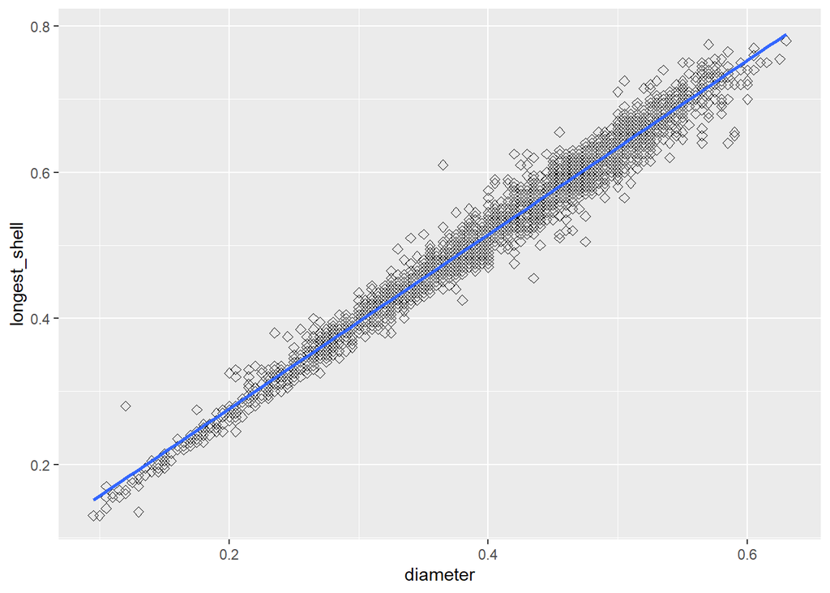

```r
ggplot(training, aes(x=diameter, y=longest_shell)) + geom_point(size=2, shape=23)+
  geom_smooth(method=lm)
```

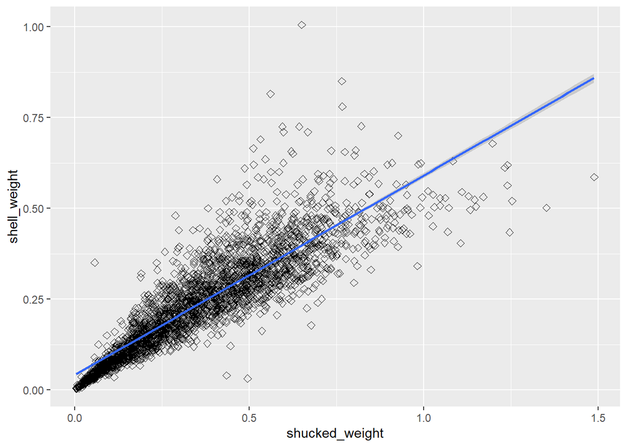

```r
ggplot(training, aes(x=shucked_weight, y=shell_weight)) + geom_point(size=2, shape=23)+
  geom_smooth(method=lm)
```

```r
#centering and scaling data
library(dplyr)
training2 <- training %>% mutate(across(where(is.numeric), scale))
training2 = subset(training2, select = -c(rings) )
abalone_recipe2 <- recipe(age ~ ., data = training2) %>%
  step_dummy(all_nominal_predictors())
```

### Question 4

Create and store a linear regression object using the `"lm"` engine.

```r
lm_model <- linear_reg() %>%
  set_engine("lm")
```

### Question 5

Now:

1. set up an empty workflow,
2. add the model you created in Question 4, and
3. add the recipe that you created in Question 3.

```r
lm_wflow <- workflow() %>%
  add_model(lm_model) %>%
  add_recipe(abalone_recipe2)

lm_fit <- fit(lm_wflow, training)

lm_fit %>%
  extract_fit_parsnip() %>%
  tidy()
```

```
## # A tibble: 10 × 5
##    term           estimate std.error statistic  p.value
##    <chr>             <dbl>     <dbl>     <dbl>    <dbl>
##  1 (Intercept)      5.49      0.353     15.5   2.16e-52
##  2 longest_shell    1.06      2.23       0.477 6.34e- 1
##  3 diameter         9.50      2.71       3.51  4.61e- 4
##  4 height           9.01      1.68       5.36  9.05e- 8
##  5 whole_weight     8.25      0.856      9.63  1.25e-21
##  6 shucked_weight -18.6       0.953    -19.5   8.43e-80
##  7 viscera_weight  -9.85      1.55      -6.33  2.75e-10
##  8 shell_weight     9.09      1.32       6.89  6.71e-12
##  9 type_I          -0.912     0.123     -7.42  1.56e-13
## 10 type_M           0.0454    0.0993     0.457 6.48e- 1
```

### Question 6

Use your `fit()` object to predict the age of a hypothetical female abalone with longest_shell = 0.50, diameter = 0.10, height = 0.30, whole_weight = 4, shucked_weight = 1, viscera_weight = 2, shell_weight = 1.

```r
testdata <- data.frame (longest_shell  = 0.50,
                  diameter = 0.10,
                  height = 0.30,
                  whole_weight = 4,
                  shucked_weight = 1,
                  viscera_weight = 2,
                  shell_weight = 1,
                  type = 'F')

prediction <- predict(lm_fit, new_data = testdata)
prediction
```

```
## # A tibble: 1 × 1
##   .pred
##   <dbl>
## 1  13.5
```

### Question 7

Now you want to assess your model’s performance. To do this, use the `yardstick` package:

1. Create a metric set that includes *R<sup>2</sup>*, RMSE (root mean squared error), and MAE (mean absolute error).
2. Use `predict()` and `bind_cols()` to create a tibble of your model’s predicted values from the **training data** along with the actual observed ages (these are needed to assess your model’s performance).
3. Finally, apply your metric set to the tibble, report the results, and interpret the *R<sup>2</sup>* value.

```r
library(yardstick)
multi_metric <- metric_set(rsq, rmse, mae)

prediction <- predict(lm_fit, new_data = training)
colnames(prediction)[1] ="Prediction"
prediction_table <- bind_cols(training$age, prediction, id=NULL)
colnames(prediction_table)[1] = "Age"
prediction_table
```

```
## # A tibble: 2,923 × 2
##      Age Prediction
##    <dbl>      <dbl>
##  1   9.5       8.15
##  2   6.5       8.12
##  3  10.5      13.2
##  4  10.5       7.62
##  5  11.5       9.70
##  6   8.5       9.80
##  7  13.5      12.8
##  8  10.5      10.8
##  9  11.5      12.4
## 10  12.5       9.94
## # … with 2,913 more rows
```

```r
training %>%
  multi_metric(truth = prediction_table$Age, estimate = prediction_table$Prediction)
```

```
## # A tibble: 3 × 3
##   .metric .estimator .estimate
##   <chr>   <chr>          <dbl>
## 1 rsq     standard       0.535
## 2 rmse    standard       2.18
## 3 mae     standard       1.57
```

#### Answer:

The *R<sup>2</sup>* value of this model is 0.535, RMSE is 2.181, and the MAE is 1.574.  
Because the *R<sup>2</sup>* value is 0.535, 53.5% of the total variability observed in Age is explained by the model.